# Using custom priors, likelihood, or movements in outbreaker2

Thibaut Jombart

2025-12-16

In this vignette, we show how custom functions for priors, likelihood, or movement of parameters and augmented data can be used in *outbreaker2*. In all these functions, the process will be similar:

1. write your own function with the right arguments
2. pass this function as an argument to a `custom...` function
3. pass the result to *outbreaker2*

Note that 2-3 can be a single step if passing the function to the arguments of *outbreaker2* directly. Also note that **all priors and likelihoods are expected on a log scale**. Finally, also note that while the various `custom...` functions will try to some extent to check that the provided functions are valid, such tests are very difficult to implement. In short: you are using these custom features at your own risks - make sure these functions work before passing them to *outbreaker2*.

# Customising priors

Priors of *outbreaker2* must be a function of an `outbreaker_param` list (see `?outbreaker_param`). Here, we decide to use a step function rather than the default Beta function as a prior for *pi*, the reporting probability, and a flat prior between 0 and 1 for the mutation rate (which is technically a probability in the basic genetic model used in *outbreaker2*).

We start by defining two functions: an auxiliary function `f` which returns values on the natural scale, and which we can use for plotting the prior distribution, and then a function `f_pi` which will be used for the customisation.

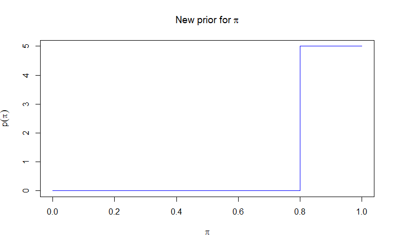

```r
f <- function(pi) {
    ifelse(pi < 0.8, 0, 5)
}

f_pi <- function(param) {
    log(f(param$pi))
}

plot(f, type = "s", col = "blue",
     xlab = expression(pi), ylab = expression(p(pi)),
     main = expression(paste("New prior for ", pi)))
```

While `f` is a useful function to visualise the prior, `f_pi` is the function which will be passed to `outbreaker`. To do so, we pass it to `custom_priors`:

```r
library(outbreaker2)

f_mu <- function(param) {
  if (param$mu < 0 || param$mu > 1) {
    return(-Inf)
  } else {
    return(0.0)
  }

}

priors <- custom_priors(pi = f_pi, mu = f_mu)
priors
```

```
#>
#>
#>  ///// outbreaker custom priors ///
#>
#> class: custom_priors list
#> number of items: 4
#>
#> /// custom priors set to NULL (default used) //
#> $eps
#> NULL
#>
#> $lambda
#> NULL
#>
#> /// custom priors //
#> $mu
#> function (param)
#> {
#>     if (param$mu < 0 || param$mu > 1) {
#>         return(-Inf)
#>     }
#>     else {
#>         return(0)
#>     }
#> }
#>
#> $pi
#> function (param)
#> {
#>     log(f(param$pi))
#> }
```

Note that `custom_priors` does more than just adding the custom function to a list. For instance, the following customisations are all wrong, and rightfully rejected:

```r
## wrong: not a function
## should be pi = function(x){0.0}
custom_priors(pi = 0.0)
```

```
#> Error in custom_priors(pi = 0): The following priors are not functions: pi
```

```r
## wrong: two arguments
custom_priors(pi = function(x, y){0.0})
```

```
#> Error in custom_priors(pi = function(x, y) {: The following priors dont' have a single argument: pi
```

We can now use the new priors to run `outbreaker` on the `fake_outbreak` data (see *introduction vignette*):

```r
dna <- fake_outbreak$dna
dates <- fake_outbreak$sample
w <- fake_outbreak$w
data <- outbreaker_data(dna = dna, dates = dates, w_dens = w)

## we set the seed to ensure results won't change
set.seed(1)


res <- outbreaker(data = data, priors = priors)
```

We can check the results first by looking at the traces, and then by plotting the posterior distributions of `pi` and `mu`, respectively:

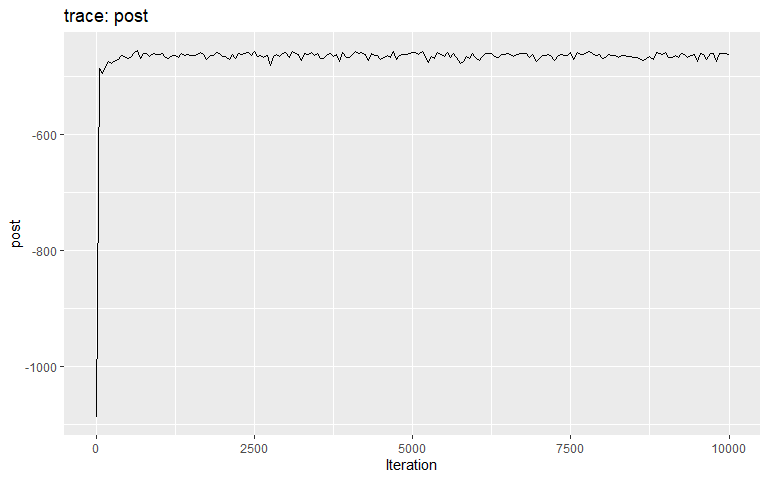

```r
plot(res)
```

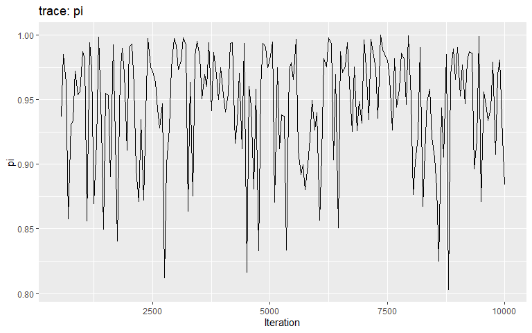

```r
plot(res, "pi", burnin = 500)
```

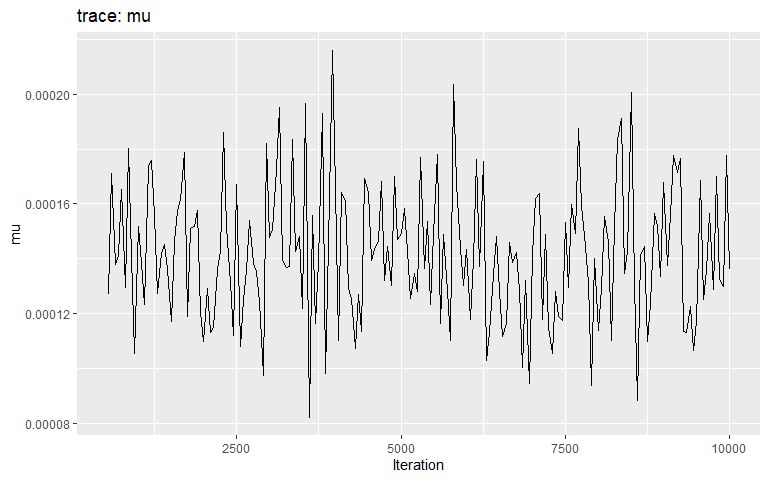

```r
plot(res, "mu", burnin = 500)
```

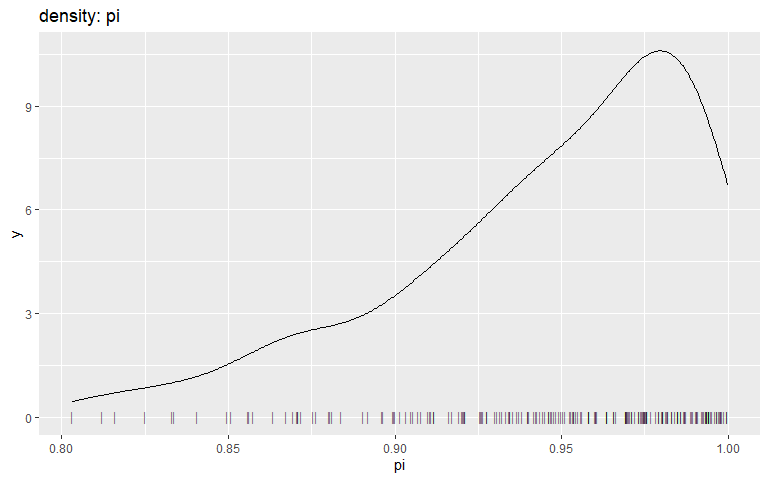

```r
plot(res, "pi", type = "density", burnin = 500)
```

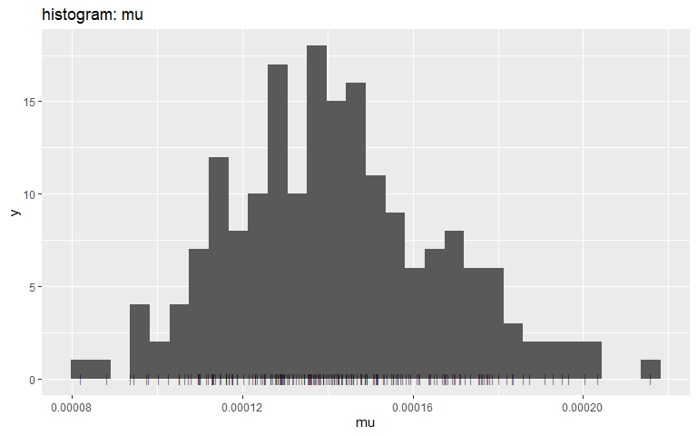

```r
plot(res, "mu", type = "hist", burnin = 500)
```

Note that we are using density and histograms here for illustrative purposes, but there is no reason to prefer one or the other for a specific parameter.

- Avoid ‘cliffs’, i.e. sharp drops in the posterior landscape, typically created by using step-functions in likelihoods and in priors.
- Use larger samples, i.e. run more MCMC iterations.
- Use a different sampler, better than Metropolis-Hasting at deriving samples from multi-modal distributions.

Because we know what the real transmission tree is for this dataset, we can assess how the new priors impacted the inference of the transmission tree.

```r
summary(res, burnin = 500)
```

```
#> $step
#>    first     last interval  n_steps
#>      550    10000       50      190
#>
#> $post
#>    Min. 1st Qu.  Median    Mean 3rd Qu.    Max.
#>  -481.1  -467.5  -463.9  -464.7  -461.4  -456.7
#>
#> $like
#>    Min. 1st Qu.  Median    Mean 3rd Qu.    Max.
#>  -482.7  -469.1  -465.5  -466.3  -463.0  -458.3
#>
#> $prior
#>    Min. 1st Qu.  Median    Mean 3rd Qu.    Max.
#>   1.609   1.609   1.609   1.609   1.609   1.609
#>
#> $mu
#>      Min.   1st Qu.    Median      Mean   3rd Qu.      Max.
#> 8.215e-05 1.254e-04 1.400e-04 1.419e-04 1.566e-04 2.159e-04
#>
#> $pi
#>    Min. 1st Qu.  Median    Mean 3rd Qu.    Max.
#>  0.8031  0.9207  0.9556  0.9453  0.9813  0.9999
#>
#> $tree
#>    from to time     support generations
#> 1    NA  1   -1          NA          NA
#> 2     1  2    1 1.000000000           1
#> 3     2  3    3 1.000000000           1
#> 4    NA  4    3 0.005263158          NA
#> 5     3  5    4 0.994736842           1
#> 6     9  6    6 1.000000000           1
#> 7     4  7    5 0.994736842           1
#> 8     5  8    6 0.989473684           1
#> 9     4  9    5 0.968421053           1
#> 10    6 10    8 1.000000000           1
#> 11    7 11    7 0.689473684           1
#> 12    5 12    7 0.826315789           1
#> 13    9 13    7 1.000000000           1
#> 14    5 14    7 0.768421053           1
#> 15    5 15    7 0.752631579           1
#> 16    7 16    8 0.794736842           1
#> 17    7 17    7 0.626315789           1
#> 18    8 18    9 0.431578947           1
#> 19    9 19    8 1.000000000           1
#> 20   10 20   10 0.968421053           1
#> 21   11 21   10 0.973684211           1
#> 22   11 22   10 1.000000000           1
#> 23   13 23    9 1.000000000           1
#> 24   13 24    9 1.000000000           1
#> 25   13 25    9 1.000000000           1
#> 26   17 26    9 1.000000000           1
#> 27   17 27   10 1.000000000           1
#> 28   NA 28    9          NA          NA
#> 29   10 29   11 1.000000000           1
#> 30   13 30   10 1.000000000           1
```

```r
tree <- summary(res, burnin = 500)$tree

comparison <- data.frame(case = 1:30,
                         inferred = paste(tree$from),
             true = paste(fake_outbreak$ances),
             stringsAsFactors = FALSE)

comparison$correct <- comparison$inferred == comparison$true
comparison
```

```
#>    case inferred true correct
#> 1     1       NA   NA    TRUE
#> 2     2        1    1    TRUE
#> 3     3        2    2    TRUE
#> 4     4       NA   NA    TRUE
#> 5     5        3    3    TRUE
#> 6     6        9    4   FALSE
#> 7     7        4    4    TRUE
#> 8     8        5    5    TRUE
#> 9     9        4    6   FALSE
#> 10   10        6    6    TRUE
#> 11   11        7    7    TRUE
#> 12   12        5    8   FALSE
#> 13   13        9    9    TRUE
#> 14   14        5    5    TRUE
```

[output cut: 16 more lines]

```r
mean(comparison$correct)
```

```
#> [1] 0.9
```

# Customizing likelihood

Likelihood functions customisation works identically to prior functions. The only difference is that custom functions will take two arguments (`data` and `param`) instead of one in the prior functions. The function used to specify custom likelihood is `custom_likelihoods`. Each custom function will correspond to a specific likelihood component:

```r
custom_likelihoods()
```

```
#>
#>
#>  ///// outbreaker custom likelihoods ///
#>
#> class: custom_likelihoods list
#> number of items: 5
#>
#> /// custom likelihoods //
#> $genetic
#> $genetic[[1]]
#> NULL
#>
#> $genetic[[2]]
#> [1] 0
#>
#>
#> $reporting
#> $reporting[[1]]
#> NULL
#>
#> $reporting[[2]]
#> [1] 0
#>
#>
#> $timing_infections
#> $timing_infections[[1]]
#> NULL
#>
#> $timing_infections[[2]]
#> [1] 0
#>
#>
#> $timing_sampling
#> $timing_sampling[[1]]
#> NULL
#>
#> $timing_sampling[[2]]
#> [1] 0
#>
#>
#> $contact
#> $contact[[1]]
#> NULL
#>
#> $contact[[2]]
#> [1] 0
```

see `?custom_likelihoods` for details of these components, and see the section ‘Extending the model’ for new, other components. As for `custom_priors`, a few checks are performed by `custom_likelihoods`:

```r
## wrong: not a function
custom_likelihoods(genetic = "fubar")
```

```
#> Error in custom_likelihoods(genetic = "fubar"): The following likelihoods are not functions: genetic
```

```r
## wrong: only one argument
custom_likelihoods(genetic = function(x){ 0.0 })
```

```
#> Error in custom_likelihoods(genetic = function(x) {: The following likelihoods do not have arity two or three: genetic
```

A trivial customisation is to disable some or all of the likelihood components of the model by returning a finite constant. Here, we apply this to two cases: first, we will disable all likelihood components as a sanity check, making sure that the transmission tree landscape is explored freely by the MCMC. Second, we will recreate the [Wallinga & Teunis (1994)](http://dx.doi.org/10.1093/aje/kwh255) model, by disabling specific components.

## A null model

```r
f_null <- function(data, param) {
   return(0.0)
}

null_model <- custom_likelihoods(genetic = f_null,
                                 timing_sampling = f_null,
                                 timing_infections = f_null,
                                 reporting = f_null,
                                 contact = f_null)

null_model
```

```
#>
#>
#>  ///// outbreaker custom likelihoods ///
#>
#> class: custom_likelihoods list
#> number of items: 5
#>
#> /// custom likelihoods //
#> $genetic
#> $genetic[[1]]
#> function (data, param)
#> {
#>     return(0)
#> }
#>
#> $genetic[[2]]
#> [1] 2
#>
#>
#> $reporting
#> $reporting[[1]]
#> function (data, param)
#> {
#>     return(0)
#> }
#>
#> $reporting[[2]]
#> [1] 2
#>
#>
#> $timing_infections
#> $timing_infections[[1]]
#> function (data, param)
#> {
#>     return(0)
#> }
#>
#> $timing_infections[[2]]
#> [1] 2
#>
#>
#> $timing_sampling
#> $timing_sampling[[1]]
#> function (data, param)
#> {
#>     return(0)
#> }
#>
#> $timing_sampling[[2]]
#> [1] 2
#>
#>
#> $contact
#> $contact[[1]]
#> function (data, param)
#> {
#>     return(0)
#> }
#>
#> $contact[[2]]
#> [1] 2
```

We also specify settings via the `config` argument to avoid detecting imported cases, reduce the number of iterations and sampling each of them:

```r
null_config <- list(find_import = FALSE,
n_iter = 500,
sample_every = 1)

set.seed(1)

res_null <- outbreaker(data = data,
config = null_config,
likelihoods = null_model)
```

[output not shown]

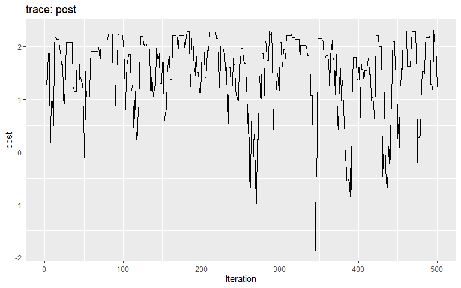

```r
plot(res_null)
```

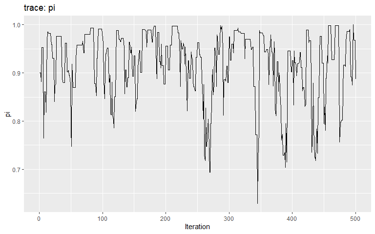

```r
plot(res_null, "pi")
```

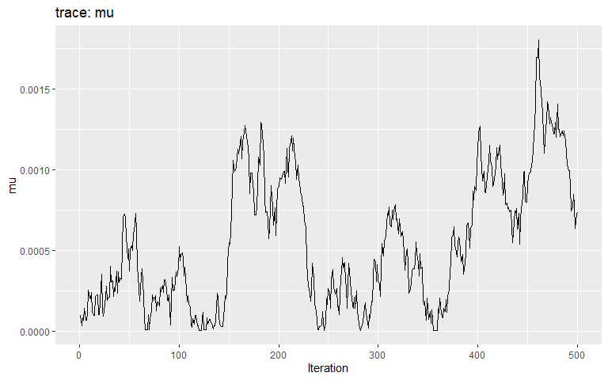

```r
plot(res_null, "mu")
```

By typical MCMC standards, these traces look appalling, as they haven’t reach stationarity (i.e. same mean and variance over time), and are grossly autocorrelated in parts. Fair enough, as these are only the first 500 iterations of the MCMC, so that autocorrelation is expected. In fact, what we observe here literally is the random walk across the posterior landscape, which in this case is only impacted by the priors.

We can check that transmission trees are indeed freely explored:

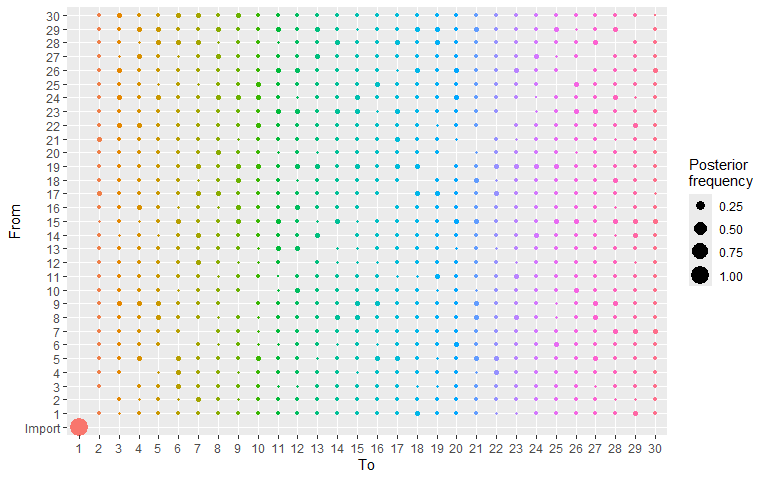

```r
plot(res_null, type = "alpha")
```

Do **not** try to render the corresponding network using `plot(..., type = "network")` as the force-direction algorithm will go insane. However, this network can be visualised using *igraph*, extracting the edges and nodes from the plot (without displaying it):

```r
## extract nodes and edges from the visNetwork object
temp <- plot(res_null, type = "network", min_support = 0)
class(temp)
```

```
#> [1] "visNetwork" "htmlwidget"
```

```r
head(temp$x$edges)
```

```
#>   from to value arrows   color
#> 1    1  2 0.040     to #CCDDFF
#> 2    1  3 0.022     to #CCDDFF
#> 3    1  4 0.034     to #CCDDFF
#> 4    1  5 0.040     to #CCDDFF
#> 5    1  6 0.034     to #CCDDFF
#> 6    1  7 0.036     to #CCDDFF
```

```r
head(temp$x$nodes)
```

```
#>   id label value   color shape shaped
#> 1  1     1 0.964 #CCDDFF   dot   star
#> 2  2     2 0.854 #B2D9E3   dot   <NA>
#> 3  3     3 0.858 #98D6C7   dot   <NA>
#> 4  4     4 0.864 #7ED2AC   dot   <NA>
#> 5  5     5 1.104 #99CAA9   dot   <NA>
#> 6  6     6 0.824 #C2C0AD   dot   <NA>
```

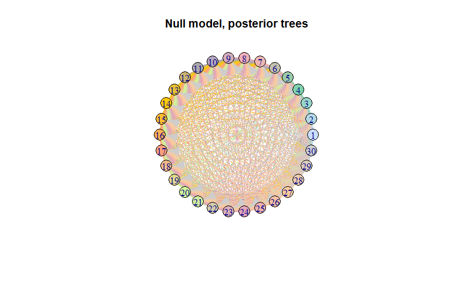

```r
## make an igraph object
library(igraph)
net_null <- graph.data.frame(temp$x$edges,
                             vertices = temp$x$nodes[1:4])
plot(net_null, layout = layout.circle,
     main = "Null model, posterior trees")
```

We can derive similar diagnostics for the number of generations between cases (`kappa`), only constrained by default settings to be between 1 and 5, and for the infection dates (*t_inf*):

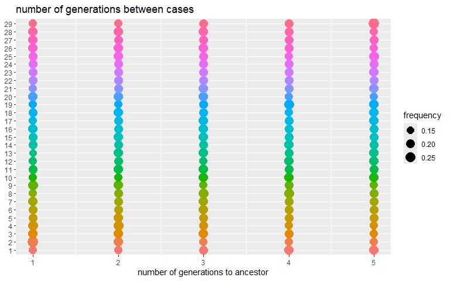

```r
plot(res_null, type = "kappa")
```

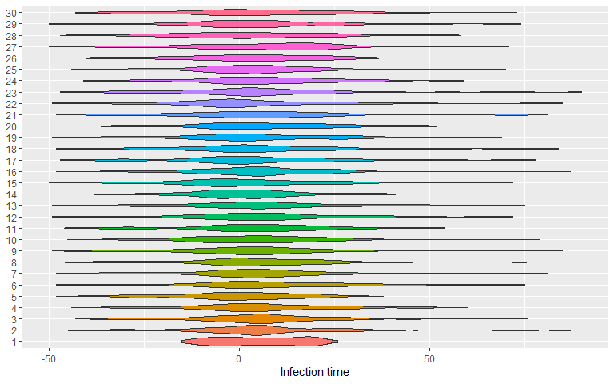

```r
plot(res_null, type = "t_inf")
```

Finally, we can verify that the distributions of `mu` and `pi` match their priors, respectively an exponential distribution with rate 1000 and a beta with parameters 10 and 1. Here, we get a qualitative assessment by comparing the observed distribution (histograms) to the densities of similar sized random samples from the priors:

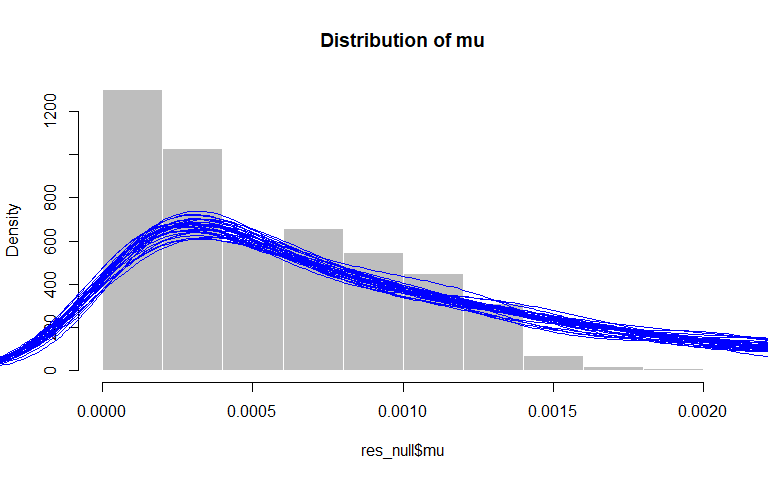

```r
par(xpd=TRUE)
hist(res_null$mu, prob = TRUE, col = "grey",
     border = "white",
     main = "Distribution of mu")

invisible(replicate(30,
     points(density(rexp(500, 1000)), type = "l", col = "blue")))
```

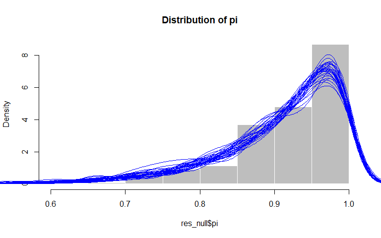

```r
hist(res_null$pi, prob = TRUE, col = "grey",
     border = "white", main = "Distribution of pi")

invisible(replicate(30,
     points(density(rbeta(500, 10, 1)), type = "l", col = "blue")))
```

## A model using symptom onset only

While these are fairly major changes, they are straightforward to implement. We first create the dataset and custom likelihood functions:

```r
onset_data <- outbreaker_data(dates = fake_outbreak$onset,
                          w_dens = fake_outbreak$w)

wt_model <- custom_likelihoods(timing_sampling = f_null,
                               reporting = f_null)
```

To fix parameters or augmented data (here, fix all `kappa` values to 1), we set the initial states to the desired values and disable the corresponding moves:

```r
wt_config <- create_config(init_kappa = 1, move_kappa = FALSE,
                           init_pi = 1, move_pi = FALSE,
                           move_mu = FALSE)
```

We can now run the analyses for this new model:

```r
set.seed(1)
res_wt <- outbreaker(data = onset_data,
                     config = wt_config,
                     likelihoods = wt_model)
```

[output not shown]

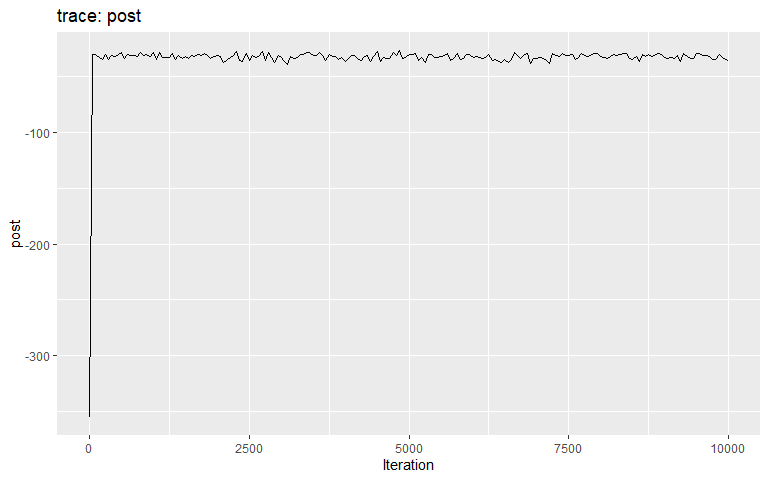

```r
plot(res_wt)
```

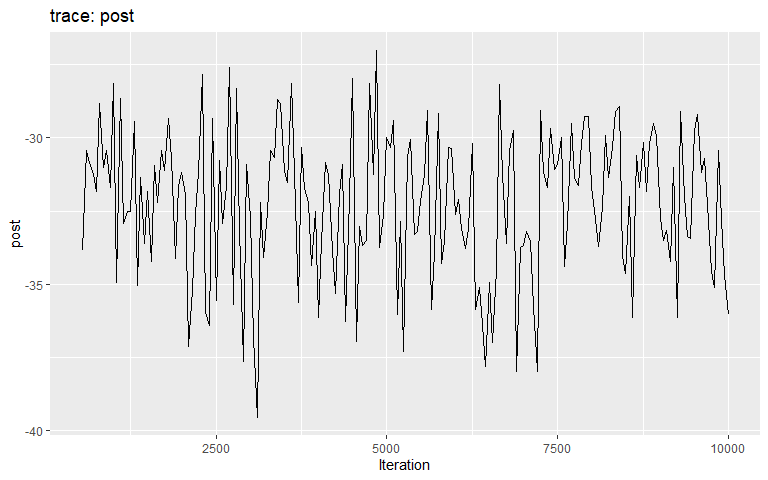

```r
plot(res_wt, burnin = 500)
```

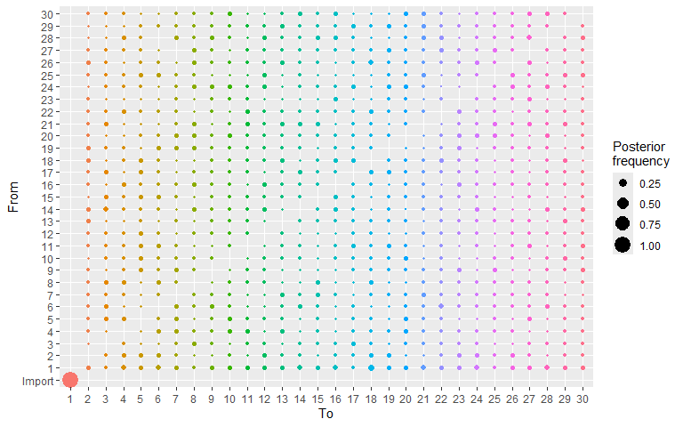

```r
plot(res_wt, burnin = 500, type = "alpha")
```

```r
summary(res_wt)
```

```
#> $step
#>    first     last interval  n_steps
#>        1    10000       50      201
#>
#> $post
#>    Min. 1st Qu.  Median    Mean 3rd Qu.    Max.
#> -354.93  -33.78  -31.93  -33.83  -30.43  -27.03
#>
#> $like
#>    Min. 1st Qu.  Median    Mean 3rd Qu.    Max.
#> -357.23  -36.08  -34.24  -36.13  -32.73  -29.33
#>
#> $prior
#>    Min. 1st Qu.  Median    Mean 3rd Qu.    Max.
#>   2.302   2.302   2.302   2.302   2.302   2.302
#>
#> $mu
#>    Min. 1st Qu.  Median    Mean 3rd Qu.    Max.
#>   1e-04   1e-04   1e-04   1e-04   1e-04   1e-04
#>
#> $pi
#>    Min. 1st Qu.  Median    Mean 3rd Qu.    Max.
#>       1       1       1       1       1       1
#>
#> $tree
#>    from to time    support generations
#> 1    NA  1  -17         NA          NA
#> 2     1  2    1 0.05970149           1
#> 3    14  3    2 0.07462687           1
#> 4     1  4    0 0.09452736           1
#> 5    12  5    3 0.06467662           1
#> 6     1  6    0 0.07462687           1
#> 7     1  7    1 0.07462687           1
#> 8    16  8    3 0.05970149           1
#> 9     1  9    1 0.06965174           1
#> 10    1 10    0 0.06467662           1
#> 11    1 11   -1 0.06467662           1
#> 12    1 12    1 0.06965174           1
#> 13    7 13    2 0.05472637           1
#> 14    1 14    0 0.08457711           1
#> 15    1 15    2 0.07462687           1
#> 16    1 16    2 0.07960199           1
#> 17    3 17    1 0.06965174           1
#> 18    1 18    0 0.11940299           1
#> 19   24 19    1 0.05970149           1
#> 20    1 20    1 0.05970149           1
#> 21    1 21    0 0.06965174           1
#> 22    6 22    2 0.07960199           1
#> 23   16 23    2 0.05970149           1
#> 24    1 24    0 0.08955224           1
#> 25   27 25    1 0.05472637           1
#> 26    1 26   -1 0.05472637           1
#> 27   28 27    2 0.09452736           1
#> 28    1 28    0 0.07462687           1
#> 29    1 29    0 0.06965174           1
#> 30    1 30    1 0.06467662           1
```

As before for the ‘null’ model, the transmission tree is very poorly resolved in this case. We use the same approach to visualise it: extract nodes and edges from the `visNetork` object, use this information to create an `igraph` object, and visualise the result using a circular layout:

```r
## extract nodes and edges from the visNetwork object
temp <- plot(res_wt, type = "network", min_support = 0.05)
class(temp)
```

```
#> [1] "visNetwork" "htmlwidget"
```

```r
head(temp$x$edges)
```

```
#>   from to      value arrows   color
#> 1    1  2 0.05970149     to #CCDDFF
#> 3    1  4 0.09452736     to #CCDDFF
#> 4    1  5 0.05970149     to #CCDDFF
#> 5    1  6 0.07462687     to #CCDDFF
#> 6    1  7 0.07462687     to #CCDDFF
#> 8    1  9 0.06965174     to #CCDDFF
```

```r
head(temp$x$nodes)
```

```
#>   id label     value   color shape shaped
#> 1  1     1 1.9203980 #CCDDFF   dot   star
#> 2  2     2 1.0348259 #B2D9E3   dot   <NA>
#> 3  3     3 0.8507463 #98D6C7   dot   <NA>
#> 4  4     4 0.9502488 #7ED2AC   dot   <NA>
#> 5  5     5 0.9353234 #99CAA9   dot   <NA>
#> 6  6     6 0.9751244 #C2C0AD   dot   <NA>
```

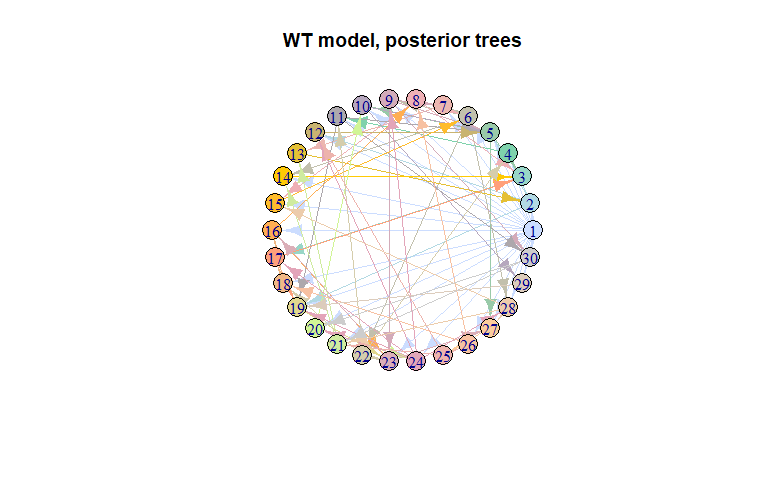

```r
## make an igraph object

net_wt <- graph.data.frame(temp$x$edges,
                             vertices = temp$x$nodes[1:4])

plot(net_wt, layout = layout.circle,
     main = "WT model, posterior trees")
```

# Customising movements

Customising movements works in similar ways to priors and likelihoods. In practice, this type of customisation is more complex as it most likely will require evaluation of likelihoods and priors, and therefore require the user to know which functions to all, and how. These are documented in the API vignette. In the following, we provide two examples:

- a (fake) Gibbs sampler for the movement of the mutation rate `mu`
- a new ‘naive’ movement of ancestries in which infectors are picked at random from all cases

But before getting into these, we need to explicit how movements are happening in *outbreaker2*.

## Movements in *outbreaker2*

At the core of the `outbreaker` function, movements are implemented as a list of functions, which are all evaluated in turn during every iteration of the MCMC. All movement functions must obey two rules:

- The first argument must be an `outbreaker_param` object (typically called `param` in the original code); see `?create_param` for details.
- All movement functions must return a valid, `outbreaker_param` object.

However, a new difficulty compared to prior or likelihood customisation is that different movements may require different components of the model, and a different set of arguments after `param`. In fact, this can be seen by examining the arguments of all the default movement functions:

```r
lapply(custom_moves(),  args)
```

```
#> $mu
#> function (param, data, config, custom_ll = NULL, custom_prior = NULL)
#> NULL
#>
#> $pi
#> function (param, data, config, custom_ll = NULL, custom_prior = NULL)
#> NULL
#>
#> $eps
#> function (param, data, config, custom_ll = NULL, custom_prior = NULL)
#> NULL
#>
#> $lambda
#> function (param, data, config, custom_ll = NULL, custom_prior = NULL)
#> NULL
#>
#> $alpha
#> function (param, data, list_custom_ll = NULL)
#> NULL
#>
#> $swap_cases
#> function (param, data, list_custom_ll = NULL)
#> NULL
#>
#> $t_inf
#> function (param, data, list_custom_ll = NULL)
#> NULL
#>
#> $kappa
#> function (param, data, config, list_custom_ll = NULL)
#> NULL
```

To handle this difficulty, *outbreaker2* transforms every movement function before running the MCMC into a new function with a single parameter `param`, attaching all other required argument to the function’s environment. The function achieving this transformation is called `bind_moves`. This function ‘knows’ what these components are for known moves listed above. For new, unknown moves, it attaches the following components, provided they are used as arguments of the new function:

- `data`: the processed data; see `?outbreaker_data`
- `config`: the configuration list; see `create_config`
- `likelihoods`: a list of custom likelihood functions; see `?custom_likelihoods`
- `priors`: a list of custom prior functions; see `?custom_priors`

See examples in `?bind_moves` for details of how this process works.

## A (fake) Gibbs sampler for `mu`

A Gibbs sampler supposes that the conditional distribution of a parameter is known and can directly be sampled from. Here, we use this principle to provide a toy example of custom movement for `mu`, assuming that this conditional distribution is always an Exponential distribution with a rate of 1000. This is easy to implement; to make sure that the function is actually used, we set a global variable changed when the function is called.

```r
move_mu <- function(param, config) {

  NEW_MOVE_HAS_BEEN_USED <<- TRUE
  param$mu <- rexp(1, 1000)
  return(param)

}

moves <- custom_moves(mu = move_mu)

quick_config <- list(n_iter = 500, sample_every = 1, find_import = FALSE)
```

Note that the new movement function `move_mu` has two arguments, and that we do not specify `config`. Internally, what happens is:

```r
## bind quick_config to function
move_mu_intern <- bind_to_function(move_mu, config = quick_config)

## new function has just one argument
move_mu_intern
```

```
#> function (param)
#> {
#>     NEW_MOVE_HAS_BEEN_USED <<- TRUE
#>     param$mu <- rexp(1, 1000)
#>     return(param)
#> }
#> <environment: 0x00000240615690f0>
```

```r
## 'config' is in the function's environment
names(environment(move_mu_intern))
```

```
#> [1] "config"
```

```r
## 'config' is actually 'quick_config'
identical(environment(move_mu_intern)$config, quick_config)
```

```
#> [1] TRUE
```

We perform a quick run using this new movement:

```r
NEW_MOVE_HAS_BEEN_USED <- FALSE

set.seed(1)
res_move_mu <- outbreaker(data, quick_config, moves = moves)
NEW_MOVE_HAS_BEEN_USED
```

```
#> [1] TRUE
```

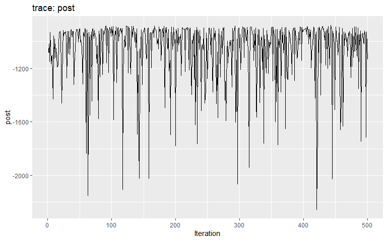

```r
plot(res_move_mu)
```

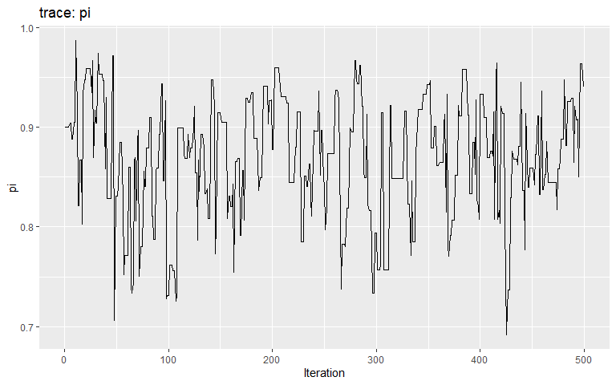

```r
plot(res_move_mu, "pi")
```

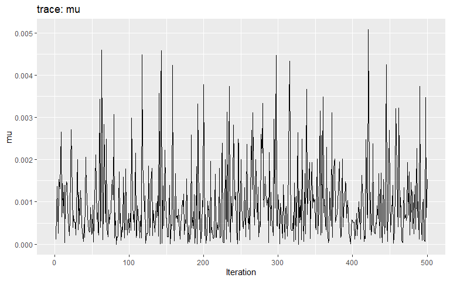

```r
plot(res_move_mu, "mu")
```

This short, full trace, clearly hasn’t mixed well (as is to be expected). But while we see the effect of accept/reject sampling (Metropolis algorithm) for `pi` with a lot of autocorrelation, the trace of `mu` shows complete independence between successive values. While the Gibbs sampler used here is not correct, this result is: a Gibbs sampler will be more efficient than the classical Metropolis(-Hasting) algorithm for a given number a iterations.

## A new movement of ancestries

Moves of ancestries are done in two ways in outbreaker: by picking ancestors at random from any prior case, and by swapping cases from a transmission link. Here, we implement a new move, which will propose infectors which have been infected on the same day of the current infector. As before, we will use global variables to keep track of the resulting movements (see `N_ACCEPT` and `N_REJECT`).

```r
api <- get_cpp_api()

new_move_ances <- function(param, data, custom_likelihoods = NULL) {

for (i in 1:data$N) {
    current_ances <- param$alpha[i]
    if (!is.na(current_ances)) {
      ## find cases infected on the same days
      current_t_inf <- param$t_inf[current_ances]
      pool <- which(param$t_inf == current_t_inf)
      pool <- setdiff(pool, i)

      if (length(pool) > 0) {
        ## propose new ancestor
        current_ll <- api$cpp_ll_all(data, param, i = i, custom_likelihoods)
        param$alpha[i] <- sample(pool, 1)
        new_ll <- api$cpp_ll_all(data, param, i = i, custom_likelihoods)

        ## likelihood ratio - no correction, move is symmetric
        ratio <- exp(new_ll - current_ll)

        ## accept / reject
        if (runif(1) <= ratio) { # accept
          N_ACCEPT <<- N_ACCEPT + 1
        } else { # reject
          N_REJECT <<- N_REJECT + 1
          param$alpha[i] <- current_ances
        }
      }
    }
  }
  return(param)
}

moves <- custom_moves(new_move = new_move_ances)
```

```r
N_ACCEPT <- 0
N_REJECT <- 0

set.seed(1)
res_new_move <- outbreaker(data, list(move_kappa = FALSE), moves = moves)
```

[output not shown]

```r
N_ACCEPT
```

```
#> [1] 148555
```

```r
N_REJECT
```

```
#> [1] 266389
```

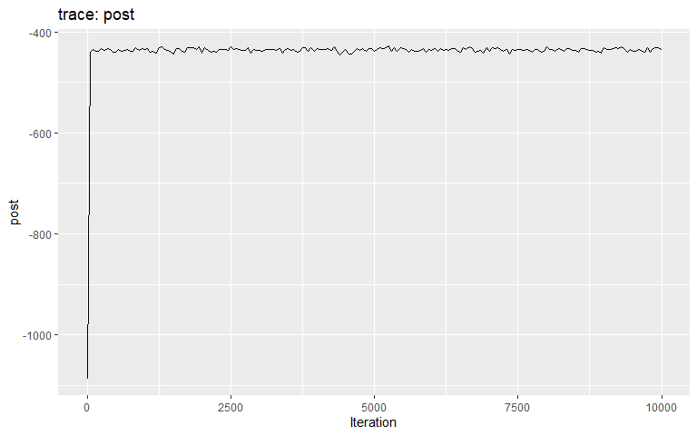

```r
plot(res_new_move)
```

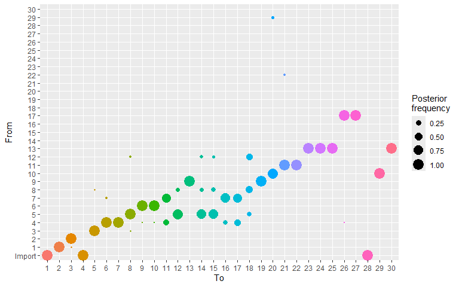

```r
plot(res_new_move, type = "alpha")
```

```r
summary(res_new_move)
```

```
#> $step
#>    first     last interval  n_steps
#>        1    10000       50      201
#>
#> $post
#>    Min. 1st Qu.  Median    Mean 3rd Qu.    Max.
#> -1087.1  -437.9  -435.2  -438.8  -433.1  -428.3
#>
#> $like
#>    Min. 1st Qu.  Median    Mean 3rd Qu.    Max.
#> -1088.4  -440.0  -437.3  -440.9  -435.1  -430.6
#>
#> $prior
#>    Min. 1st Qu.  Median    Mean 3rd Qu.    Max.
#>  0.9421  1.9836  2.1630  2.0700  2.2397  2.3024
#>
#> $mu
#>      Min.   1st Qu.    Median      Mean   3rd Qu.      Max.
#> 7.566e-05 1.229e-04 1.365e-04 1.374e-04 1.491e-04 2.117e-04
#>
#> $pi
#>    Min. 1st Qu.  Median    Mean 3rd Qu.    Max.
#>  0.8597  0.9652  0.9846  0.9748  0.9931  1.0000
#>
#> $tree
#>    from to time   support generations
#> 1    NA  1   -4        NA          NA
#> 2     1  2   -2 1.0000000           1
#> 3     2  3    0 0.9900498           1
#> 4    NA  4    0        NA          NA
#> 5     3  5    1 0.9900498           1
#> 6     4  6    2 0.9651741           1
#> 7     4  7    2 1.0000000           1
#> 8     5  8    3 0.9601990           1
#> 9     6  9    3 0.9950249           1
#> 10    6 10    4 0.9950249           1
#> 11    7 11    4 0.7014925           1
#> 12    5 12    4 0.8656716           1
#> 13    9 13    4 1.0000000           1
#> 14    5 14    4 0.7761194           1
#> 15    5 15    4 0.7412935           1
#> 16    7 16    5 0.8109453           1
#> 17    7 17    4 0.6417910           1
#> 18    8 18    6 0.4527363           1
#> 19    9 19    5 1.0000000           1
#> 20   10 20    7 0.9353234           1
#> 21   11 21    7 0.9651741           1
#> 22   11 22    7 1.0000000           1
#> 23   13 23    6 1.0000000           1
#> 24   13 24    6 1.0000000           1
#> 25   13 25    6 1.0000000           1
#> 26   17 26    6 0.9950249           1
#> 27   17 27    7 1.0000000           1
#> 28   NA 28    6        NA          NA
#> 29   10 29    8 1.0000000           1
#> 30   13 30    7 1.0000000           1
```

```r
summary(res_new_move, burnin = 5000)
```

```
#> $step
#>    first     last interval  n_steps
#>     5050    10000       50      100
#>
#> $post
#>    Min. 1st Qu.  Median    Mean 3rd Qu.    Max.
#>  -442.9  -437.8  -434.9  -435.3  -433.1  -428.3
#>
#> $like
#>    Min. 1st Qu.  Median    Mean 3rd Qu.    Max.
#>  -444.5  -439.7  -437.0  -437.4  -435.0  -430.6
#>
#> $prior
#>    Min. 1st Qu.  Median    Mean 3rd Qu.    Max.
#>   1.473   1.979   2.157   2.083   2.228   2.302
#>
#> $mu
#>      Min.   1st Qu.    Median      Mean   3rd Qu.      Max.
#> 7.792e-05 1.215e-04 1.364e-04 1.379e-04 1.551e-04 1.932e-04
#>
#> $pi
#>    Min. 1st Qu.  Median    Mean 3rd Qu.    Max.
#>  0.9120  0.9647  0.9840  0.9762  0.9918  1.0000
#>
#> $tree
#>    from to time support generations
#> 1    NA  1   -4      NA          NA
#> 2     1  2   -2    1.00           1
#> 3     2  3    0    0.99           1
#> 4    NA  4    0      NA          NA
#> 5     3  5    1    0.99           1
#> 6     4  6    2    0.98           1
#> 7     4  7    2    1.00           1
#> 8     5  8    3    0.97           1
#> 9     6  9    3    1.00           1
#> 10    6 10    4    1.00           1
#> 11    7 11    4    0.69           1
#> 12    5 12    4    0.87           1
#> 13    9 13    4    1.00           1
#> 14    5 14    4    0.80           1
#> 15    5 15    4    0.72           1
#> 16    7 16    5    0.79           1
#> 17    7 17    4    0.67           1
#> 18    8 18    6    0.42           1
#> 19    9 19    6    1.00           1
#> 20   10 20    7    0.87           1
#> 21   11 21    7    0.97           1
#> 22   11 22    7    1.00           1
#> 23   13 23    6    1.00           1
#> 24   13 24    7    1.00           1
#> 25   13 25    6    1.00           1
#> 26   17 26    6    1.00           1
#> 27   17 27    7    1.00           1
#> 28   NA 28    6      NA          NA
#> 29   10 29    8    1.00           1
#> 30   13 30    8    1.00           1
```

```r
tree2 <- summary(res_new_move, burnin = 5000)$tree

comparison <- data.frame(case = 1:30,
                         inferred = paste(tree2$from),
             true = paste(fake_outbreak$ances),
             stringsAsFactors = FALSE)

comparison$correct <- comparison$inferred == comparison$true
comparison
```

```
#>    case inferred true correct
#> 1     1       NA   NA    TRUE
#> 2     2        1    1    TRUE
#> 3     3        2    2    TRUE
#> 4     4       NA   NA    TRUE
#> 5     5        3    3    TRUE
#> 6     6        4    4    TRUE
#> 7     7        4    4    TRUE
#> 8     8        5    5    TRUE
#> 9     9        6    6    TRUE
#> 10   10        6    6    TRUE
#> 11   11        7    7    TRUE
#> 12   12        5    8   FALSE
#> 13   13        9    9    TRUE
#> 14   14        5    5    TRUE
```

[output cut: 16 more lines]

```r
mean(comparison$correct)
```

```
#> [1] 0.9666667
```